# TITLE by YOUR_NAME_HERE

# 双变量分析

### 硫酸盐的含量和ph值呈负相关,但是关联并不是太明显

### 柠檬酸的含量和ph值呈负相关

### 你发现最强的关系是什么？

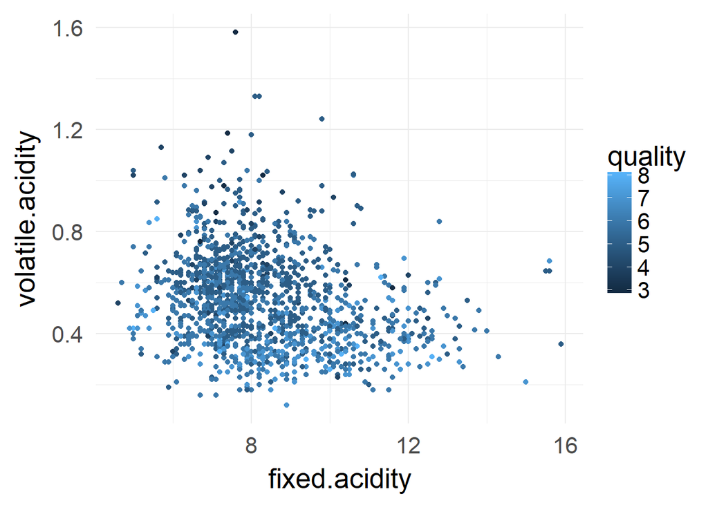

可以从图中看出质量较高的葡萄酒分布在挥发酸较低的区域

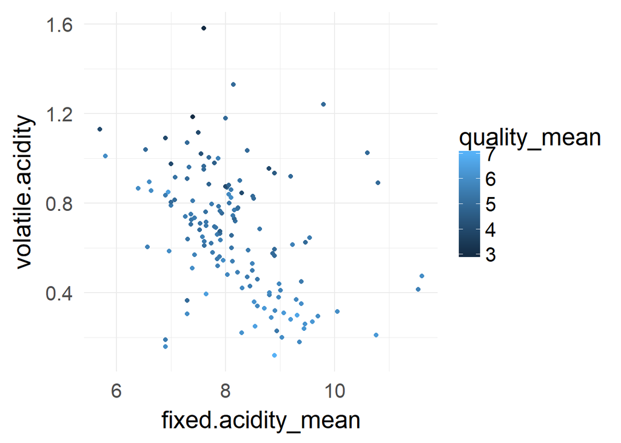

可以从图中看出品质越好的葡萄酒有着很低的挥发酸和很高的非挥发酸, 挥发酸的存在是影响酒的品质的重要因素

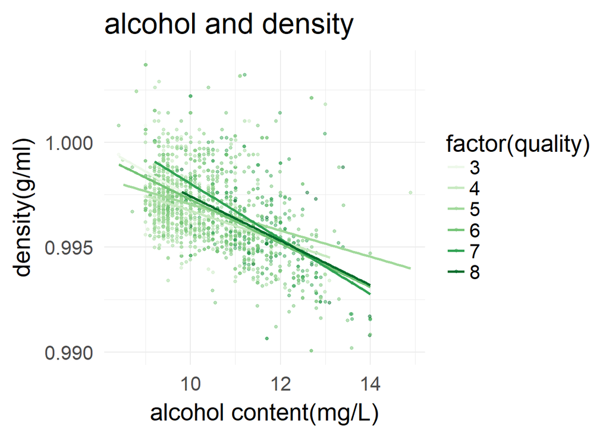

可以从图上看出密度越高,酒精度越低,同时密度低,葡萄酒的品质越好

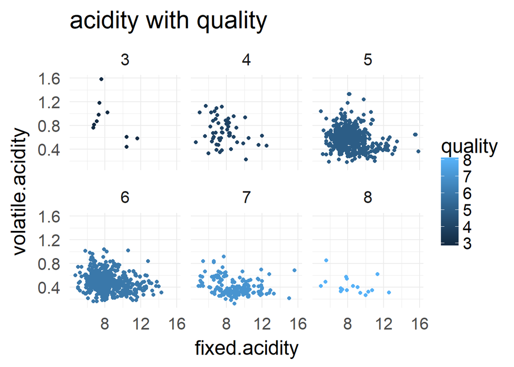

可以从图上看出品质越好的葡萄酒的挥发酸越少

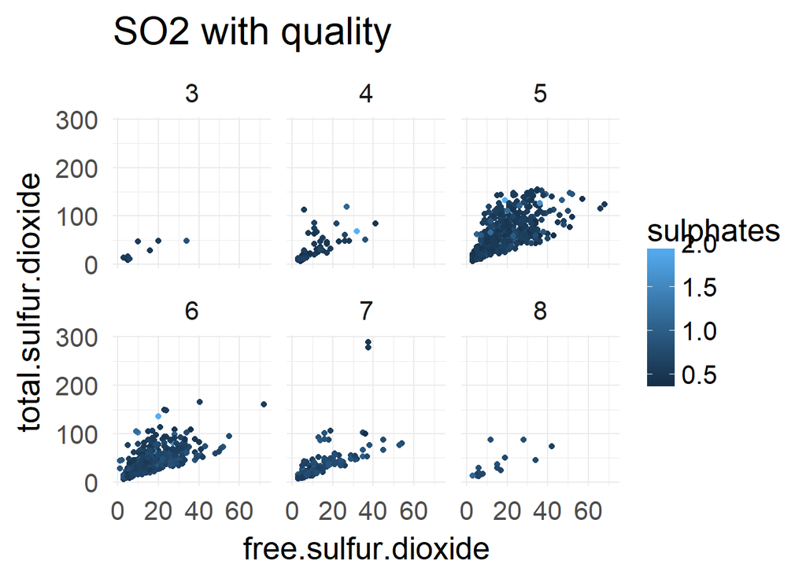

# 多变量分析

### 再根据质量进行排序,得到新的数据框架来探索挥发酸和非挥发酸对品质的影响

# 定稿图与总结

### 绘图一

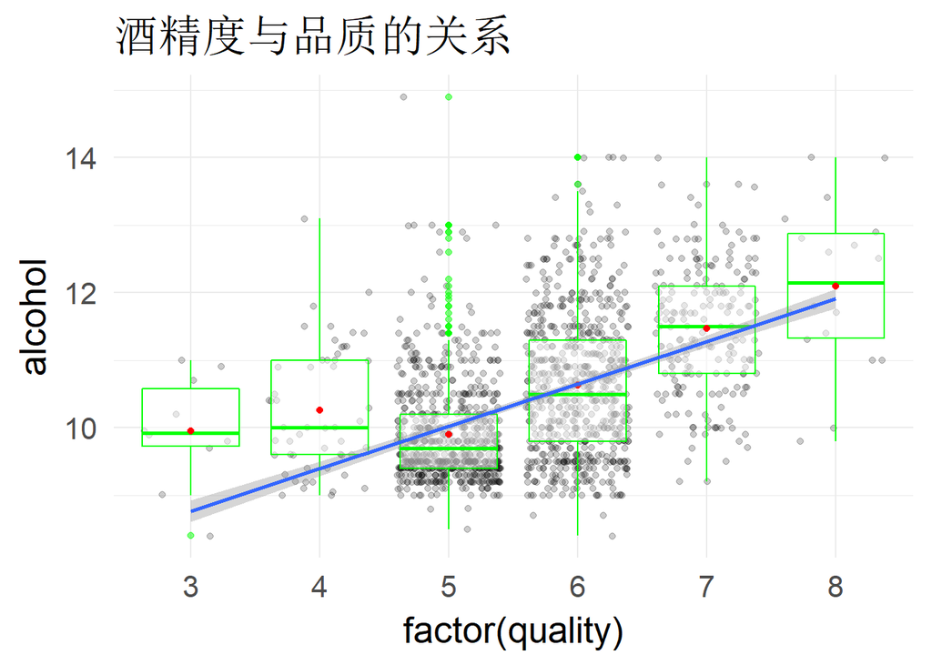

### 描述一

可以从图上看出品质越好的葡萄酒酒精度越高

### 绘图二

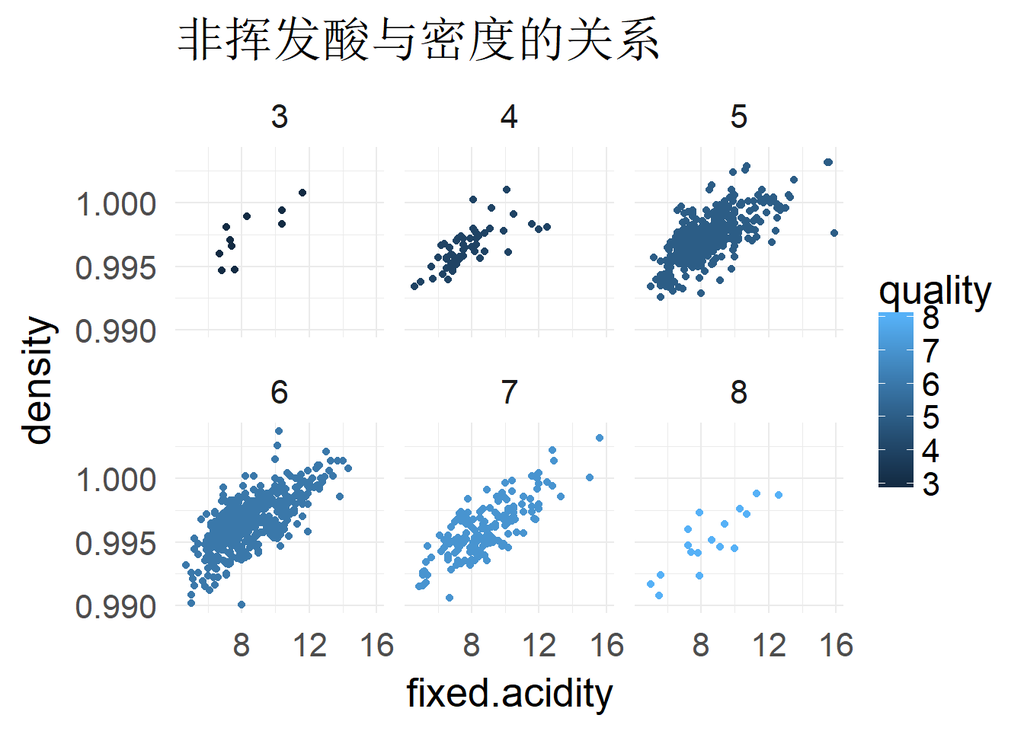

### 描述二

根据图片可以看出非挥发酸越高,葡萄酒的密度就越大

### 绘图三

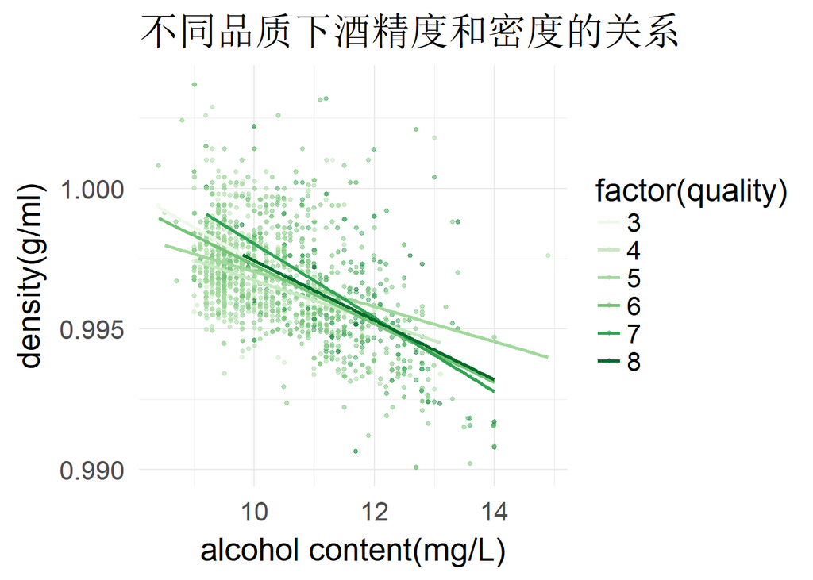

### 描述三

从图上可以看出不同品质的葡萄酒都满足酒精度越高密度越低的规则

# 反思

### 在这次的项目中我主要是分析葡萄酒质量入手来分析一些与之相关的变量

### 首先查阅资料了解示例文件中的每列的定义,并且初步进行猜测品质与哪些

### 因素有关联.

### 其次我在探索数据的过程中开始没有发现哪些变量和品质有着太多的关系,但是我通过每个变量和品质的关联图

### 可以找到具体是哪些变量的改变了葡萄酒的品质,但是美中不足的是没有价格来给我作为参考标准

### 同时数据集的数据和描述列并不是太多,如果有更多的数据.本次的分析只是大概地描述了葡萄酒质量和

### 挥发酸,酒精度,密度,含硫量来入手的,可能部分图表和数据并不是很准确,相信如果有更大更多的数据集

### 进行分析,会得出更加精确的图表和分析结果.唯一美中不足的是,如何找出挥发酸和葡

### 萄酒品质的线性模型来更加精确的描述这种关系,是我接下来要探究的问题,希望此处可

### 以得到老师的指点,这样模型的可以定义这两者中更精确的关系,得出更准确的数据